# **Universidade Federal Rural de Pernambuco** **[Departamento de Matemática](http://www.dm.ufrpe.br/)** **Disciplina: Cálculo M I** **[Prof. Ricardo Machado](https://sites.google.com/site/ricardonunesm

## R. b) Calcular $f'(x) = \displaystyle\lim_{h\rightarrow 0} \dfrac{f(x+h) - f(x)}{h} = \lim_{h\rightarrow 0} \dfrac{(x+h)^2 - x^2}{h} = $ $ = \displaystyle\lim_{h\rightarrow 0} \dfrac{x^2+2xh + h^2 - x^2}{h} = \lim_{h\rightarrow 0} \dfrac{2xh + h^2}{h} = \lim_{h\rightarrow 0} (2x + h) = 2x.$

```python
diff(x^2, x)
```

```
2*x
```

## R. c) Calcular $f'(-3) = 2\cdot(-3) = -6$

```python
diff(x^2, x)(x = -3)
```

```
-6
```

## R. d)

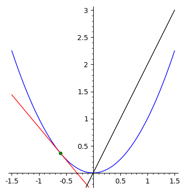

```python
grafico_f_tan(x^2, -0.6, (-1.5, 1.5), (-0.2, 3)) + plot(diff(x^2, x),(-1.5, 1.5), color = 'black')
```

## Exercício 2. Seja $f(x) = x^2$. Determine a equação da reta tangente ao gráfico de $f$ no ponto

## a) $(1, f(1))$ b) $(-1, f(-1))$

## R. a) $y-f(1) = f'(1)(x-1) \Rightarrow y = 2(x-1)+1 \Rightarrow y = 2x-1.$

```python
y = var('y')
f = x^2
(y - f(1) == diff(f, x)(x=1)*(x-1)).show()
(y == diff(f, x)(x=1)*(x-1) + f(1)).show()
```

$$\newcommand{\Bold}[1]{\mathbf{#1}}y - 1 = 2 \, x - 2$$

$$\newcommand{\Bold}[1]{\mathbf{#1}}y = 2 \, x - 1$$

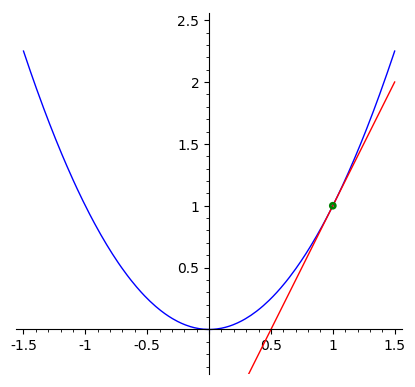

```python
grafico_f_tan(x^2 , 1, (-1.5, 1.5), (-0.3, 2.5))
```

## R. b) $y-f(-1) = f'(-1)(x-(-1)) \Rightarrow y = -2x-1$

```python
y = var('y')
f = x^2
(y - f(-1) == diff(f, x)(x=-1)*(x-(-1))).show()
(y == diff(f, x)(x=-1)*(x-(-1)) + f(-1)).show()
```

$$\newcommand{\Bold}[1]{\mathbf{#1}}y - 1 = -2 \, x - 2$$

$$\newcommand{\Bold}[1]{\mathbf{#1}}y = -2 \, x - 1$$

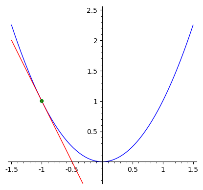

```python
grafico_f_tan(x^2 , -1, (-1.5, 1.5), (-0.3, 2.5))
```

## Exercício 3. Seja $f(x) = k$ uma função constante. Mostre que $f'(x)=0$ para todo $x$.

## R. Ex3) $f'(x) = \displaystyle \lim_{h\rightarrow 0} \frac{f(x+h)-f(x)}{h} = \lim_{h\rightarrow 0} \frac{k-k}{h} = \lim_{h\rightarrow 0} 0 = 0. $

## Exercício 4. Seja $f(x) = x$. Prove que $f'(x) = 1$, para todo $x$.

## R. Ex4) $f'(x) = \displaystyle \lim_{h\rightarrow 0} \frac{f(x+h)-f(x)}{h} = \lim_{h\rightarrow 0} \frac{x+h-x}{h} = \lim_{h\rightarrow 0} \frac{h}{h} = 1. $

## Exemplo 5. Seja

## $$f(x) = \begin{cases} x^2\sin\left(\frac{1}{x}\right), & x\neq 0 \\ 0, & x = 0 \end{cases}$$ Calcule, caso exista, $f'(0)$.

## R. EX5) $f'(0) = \displaystyle \lim_{x\rightarrow 0} \frac{f(x)-f(0)}{x-0} = \lim_{x\rightarrow 0} \frac{f(x)}{x} = \lim_{x\rightarrow0} x\cdot\sin\left(\frac{1}{x}\right)=0$

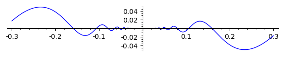

```python
p1 = plot(x^2*sin(1/x), (-0.3, 0.3), aspect_ratio=1)
p2 = plot(0, (-0.3, 0.3), color='red')
(p1+p2)
```

## Exemplo 6. Mostre que $f(x) = |x|$ não é derivável em $p=0$.

## A idéia é mostrar que os limites laterais são diferentes: $\displaystyle \lim_{x\rightarrow 0^+} \frac{f(x)-f(0)}{x-0}=1$ $\displaystyle \lim_{x\rightarrow 0^-} \frac{f(x)-f(0)}{x-0}=-1$

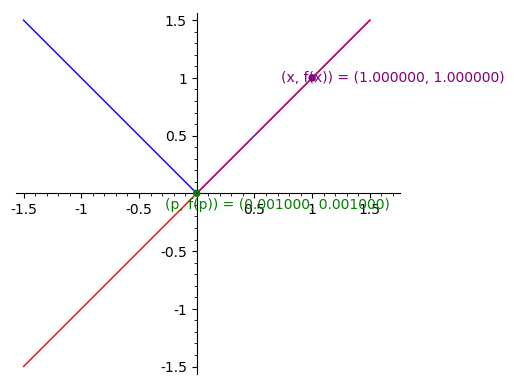

```python
anima_ate_tangente(abs(x), 1, 0.001, 0.1, (-1.5, 1.5), (-1.5, 1.5))
```

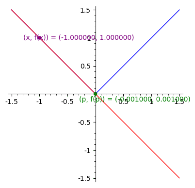

```python
anima_ate_tangente(abs(x), -1, -0.001, -0.1, (-1.5, 1.5), (-1.5, 1.5))
```